# ML_Assignment 6

2023-02-22

### Load Packages Needed for the Assignment

```r
library(tidyverse)
library(janitor)
library(yardstick)
library(stats)
library(factoextra)
library(cluster)
library(caret)
```

```r
library(NHANES)
library(e1071)
library(rpart)
library(rpart.plot)
library(pROC)
library(kernlab)
```

## Assignment Instructions:

For this assignment, you will:

1. Restrict the NHANES data to the list of 11 variables below. Partition the data into training and testing using a 70/30 split.
2. Construct three prediction models to predict diabetes using the 11 features from NHANES. You will use the following three algorithms to create your prediction models:
1. Classification Tree
2. Support Vector Classifier (i.e. Support Vector Machine with a linear classifier)
3. Logistic regression.
3. You will optimize each model using cross-validation to choose hyperparameters in the training data and then compare performance across models.
4. Select a “optimal” model and calculate final evaluation metrics in the test set.

### Step 1: Load and Prepare Dataset

```r
data(NHANES)

a6.data <- NHANES %>%
  select("Age", "Race1", "Education", "HHIncome", "Weight", "Height", "Pulse", "Diabetes", "BMI", "PhysActive", "Smoke100")

#Remove Missing Variables
a6.data <- na.omit(a6.data)

#Renove Duplicate Variables
a6.data <- distinct(a6.data)

#Centering and Scaling: Although not needed for classification trees, this would be important for SVM and logistic regression.
#set.up.preprocess<-preProcess(a6.data, method=c("center", "scale"))

#Output pre-processed values
#transformed.vals<-predict(set.up.preprocess, a6.data)
```

### Step 2: Data Partitioning

```r
set.seed(123)

train.index<-createDataPartition(a6.data$Diabetes, p=0.7, list=FALSE)

a6.data.train<-a6.data[train.index,]
a6.data.test<-a6.data[-train.index,]
```

### Step 3: Training the Model using different methods:

#### 1. Classification Tree

```r
set.seed(123)

#Creating 10-fold cross-validation and using down-sampling because of imbalance in data
train.control.class<-trainControl(method="cv", number=10, sampling="down", classProbs = T)

#Create sequence of cp parameters to try
grid.2<-expand.grid(cp=seq(0.001, 0.3, by=0.01))

#Train model
tree.diabetes <-train(Diabetes ~., data=a6.data.train, method="rpart",trControl=train.control.class, tuneGrid=grid.2)
tree.diabetes$bestTune
```

```
##      cp
## 1 0.001
```

```r
tree.diabetes
```

```
## CART
##
## 2829 samples
##   10 predictor
##    2 classes: 'No', 'Yes'
##
## No pre-processing
## Resampling: Cross-Validated (10 fold)
## Summary of sample sizes: 2546, 2546, 2546, 2546, 2547, 2546, ...
## Addtional sampling using down-sampling
##
## Resampling results across tuning parameters:
##
##   cp     Accuracy   Kappa
##   0.001  0.6726446  0.1848086
##   0.011  0.6709316  0.2144341
##   0.021  0.6702248  0.2114788
##   0.031  0.6518352  0.1989322
##   0.041  0.6518352  0.1989322
##   0.051  0.6472178  0.1911850
##   0.061  0.6363023  0.1843559
##   0.071  0.6224725  0.1803389
##   0.081  0.6224725  0.1803389
##   0.091  0.6224725  0.1803389
##   0.101  0.6224725  0.1803389
##   0.111  0.6224725  0.1803389
##   0.121  0.6224725  0.1803389
##   0.131  0.6224725  0.1803389
##   0.141  0.6224725  0.1803389
##   0.151  0.6224725  0.1803389
##   0.161  0.6224725  0.1803389
##   0.171  0.6224725  0.1803389
##   0.181  0.6224725  0.1803389
##   0.191  0.6224725  0.1803389
##   0.201  0.6224725  0.1803389
##   0.211  0.6224725  0.1803389
##   0.221  0.6224725  0.1803389
##   0.231  0.6224725  0.1803389
##   0.241  0.6224725  0.1803389
##   0.251  0.6224725  0.1803389
##   0.261  0.6224725  0.1803389
##   0.271  0.6224725  0.1803389
##   0.281  0.6224725  0.1803389
##   0.291  0.6224725  0.1803389
##
## Accuracy was used to select the optimal model using the largest value.
## The final value used for the model was cp = 0.001.
```

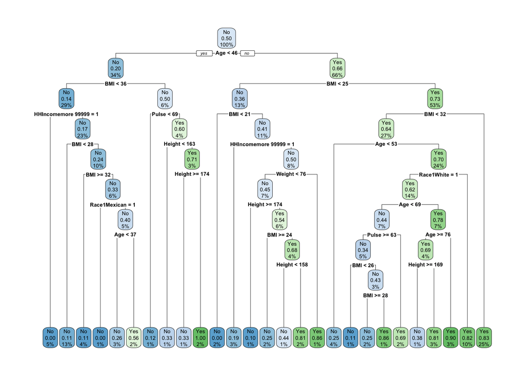

```r
rpart.plot(tree.diabetes$finalModel)
```

```r
#Note you can obtain variable importance on the final model within training data
varImp(tree.diabetes)
```

```
## rpart variable importance
##
##   only 20 most important variables shown (out of 35)
##
##                         Overall
## Age                     100.000
## BMI                      89.936
## Weight                   53.262
## PhysActiveYes            29.921
## Height                   26.160
## Pulse                    24.373
## EducationCollege Grad    23.467
## HHIncomemore 99999       17.664
## Race1White               13.174
## HHIncome75000-99999       6.656
## Education9 - 11th Grade   5.380
## EducationHigh School      4.971
## HHIncome45000-54999       3.210
## HHIncome 5000-9999        2.975
## Smoke100Yes               2.426
## Race1Mexican              2.062
## EducationSome College     1.905
## HHIncome25000-34999       1.145
## `EducationSome College`   0.000
## Race1Hispanic             0.000
```

```r
#Note you can get accuracy metric and confusion matrix from training.
cm.tree <- confusionMatrix(tree.diabetes)
cm.tree
```

```
## Cross-Validated (10 fold) Confusion Matrix
##
## (entries are percentual average cell counts across resamples)
##
##           Reference
## Prediction   No  Yes
##        No  59.2  3.8
##        Yes 29.0  8.1
##
##  Accuracy (average) : 0.6727
```

After cross-validating hyperparameters and evaluating on the training set, the average accuracy of the classification tree model is **0.6727**.

#### 2. Support Vector Classifier (i.e. Support Vector Machine with a linear classifier)

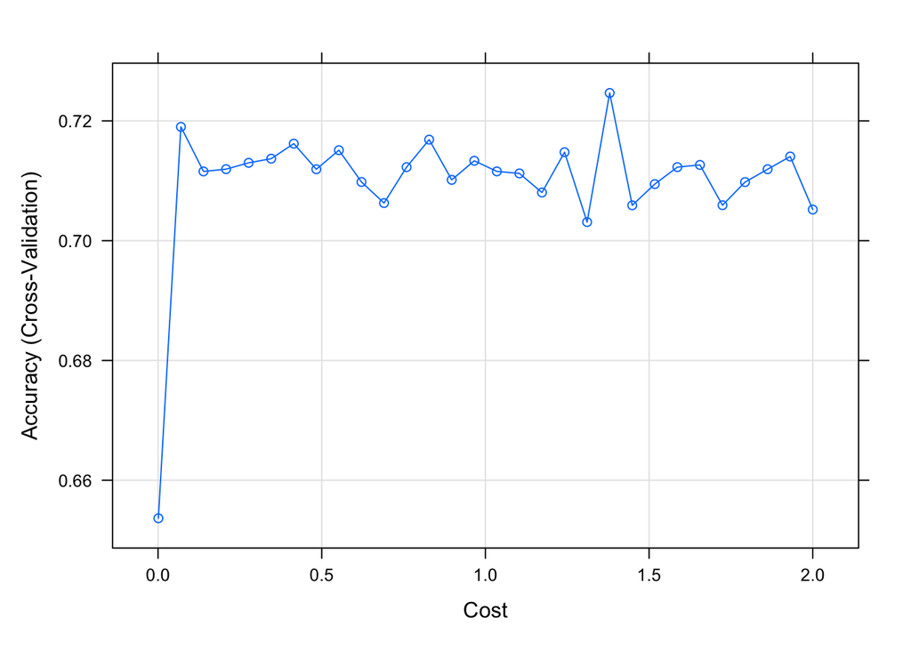

```r
set.seed(123)

#Creating 10-fold cross-validation and using down-sampling because of imbalance in data
train.control.class<-trainControl(method="cv", number=10, sampling="down", classProbs = T)

#Incorporate different values for cost (C)
svm.diabetes <- train(Diabetes ~ ., data = a6.data.train, method="svmLinear",
                   trControl=train.control.class,
                   preProcess=c("center", "scale"),
                   tuneGrid=expand.grid(C=seq(0.001,2, length=30)))

#Visualize accuracy versus values of C
plot(svm.diabetes)
```

```r
#See information about final model
svm.diabetes$finalModel
```

```
## Support Vector Machine object of class "ksvm"
##
## SV type: C-svc  (classification)
##  parameter : cost C = 1.37962068965517
##
## Linear (vanilla) kernel function.
##
## Number of Support Vectors : 398
##
## Objective Function Value : -529.7969
## Training error : 0.240299
## Probability model included.
```

```r
#Obtain metrics of accuracy from training
confusionMatrix(svm.diabetes)
```

```
## Cross-Validated (10 fold) Confusion Matrix
##
## (entries are percentual average cell counts across resamples)
##
##           Reference
## Prediction   No  Yes
##        No  63.3  2.7
##        Yes 24.8  9.2
##
##  Accuracy (average) : 0.7246
```

After cross-validating hyperparameters and evaluating on the training set, the average accuracy of the SVM model is **0.7246**.

#### 3. Logistic Regression Model

```r
set.seed(123)

#Setting a cross validation control
cv_results <- trainControl(method = "cv", number = 10, sampling = "down", classProbs = T)

#Training a logistic regression model with cross validation
log.diabetes <- train(Diabetes ~ ., data = a6.data.train,
                      method = "glm",
                      family = "binomial",
                      trControl = cv_results,
                      preProc=c("center", "scale"))


log.diabetes$results
```

```
##   parameter  Accuracy     Kappa AccuracySD    KappaSD
## 1      none 0.7186289 0.2586378 0.03169238 0.04918597
```

```r
confusionMatrix(log.diabetes)
```

```
## Cross-Validated (10 fold) Confusion Matrix
##
## (entries are percentual average cell counts across resamples)
##
##           Reference
## Prediction   No  Yes
##        No  63.0  2.9
##        Yes 25.2  8.9
##
##  Accuracy (average) : 0.7186
```

After cross-validating hyperparameters and evaluating on the training set, the average accuracy of the logistic regression model is **0.7186**.

### Step 4: Final Model Evaluation

After comparing the accuracies of all 3 models, the SVM model has the highest accuracy. I would go ahead with this model for the final evaluation.

```r
set.seed(123)

svm.prediction.final <- predict(svm.diabetes,newdata = a6.data.test)
svm.confusion.matrix <- confusionMatrix(svm.prediction.final, a6.data.test$Diabetes, positive = "Yes")

postResample(svm.prediction.final,a6.data.test$Diabetes)
```

```
##  Accuracy     Kappa
## 0.7010735 0.2479912
```

```r
svm.confusion.matrix
```

```
## Confusion Matrix and Statistics
##
##           Reference
## Prediction  No Yes
##        No  737  31
##        Yes 331 112
##
##                Accuracy : 0.7011
##                  95% CI : (0.6744, 0.7268)
##     No Information Rate : 0.8819
##     P-Value [Acc > NIR] : 1
##
##                   Kappa : 0.248
##
##  Mcnemar's Test P-Value : <2e-16
##
##             Sensitivity : 0.78322
##             Specificity : 0.69007
##          Pos Pred Value : 0.25282
##          Neg Pred Value : 0.95964
##              Prevalence : 0.11808
##          Detection Rate : 0.09249
##    Detection Prevalence : 0.36581
##       Balanced Accuracy : 0.73665
##
##        'Positive' Class : Yes
##
```

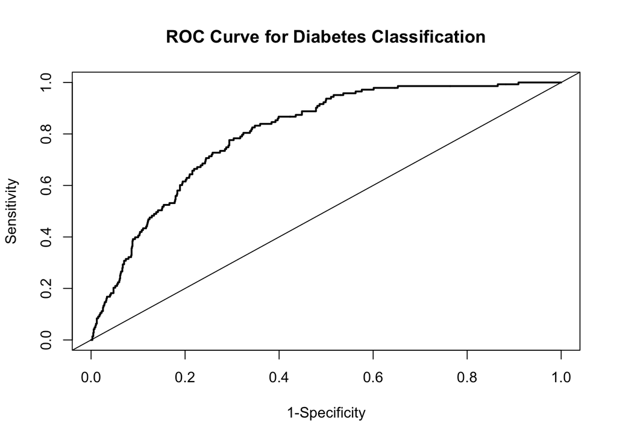

```r
#Create ROC Curve for Analysis
pred.prob<-predict(svm.diabetes, a6.data.test, type="prob")

#Another potential evaluation: Area under the Reciver Operating Curve (AUROC)
svm.analysis <- roc(response=a6.data.test$Diabetes, predictor=pred.prob[,2])
plot(1-svm.analysis$specificities,svm.analysis$sensitivities,type="l",
ylab="Sensitivity",xlab="1-Specificity",col="black",lwd=2,
main = "ROC Curve for Diabetes Classification")
abline(a=0,b=1)
```

```r
#Area Under the Curve
svm.analysis$auc
```

```
## Area under the curve: 0.8038
```

**Final Evaluation Metrics for the SVM Model**:

**Accuracy** : 0.7011 (95% CI: 0.6744 - 0.7268) **Sensitivity** : 0.78322  
**Specificity** : 0.69007

**ROC Area Under the Curve**: 0.8038

**5. List and describe at least two limitations/considerations of the model generated by this analysis. Limitations can be analytical or they can be considerations that need to be made regarding how the model would be applied in practice.**

- 1. **Causal Model vs Predictive Model**: The SVM model created through my analysis is effective in predicting the Diabetes among patients based on different features from a publically available dataset, it may be inappropriate to make causal inference about the risk factors that cause diabetes in different patients. To make causal inference, we need methodology based on theory with a preexisting causal hypothesis and selected features to be used in the model, with other epidemiology study considerations.
- 2. **Generalizability of the SVM Model**: In this analysis, the SVM model was trained on NHANES data. The predictions and performance metrics of this model may not apply to populations from different countries or populations having different disease prevalence, or differing proportions of demographic, environment, or social factors. Moreover, NHANES data is collected through self-reported surveys, which may also introduce bias within the data set that may not reflect the true data.